# PEC_1

Victor H. Ayala Sánchez

13/3/2022

**Cargamos las librerías necesarias**

```r
library(knitr)
library(tidyverse)
```

```r
library(tidyr)
library(dplyr)
library(stringr)
library(ggplot2)
library(forcats)
library(VIM)
library(Rcpp)
```

# 1.Carga del Archivo

```r
dataFrame <- read.csv('CensusIncomedataset.csv', sep = ";")
head(dataFrame)
```

```
##   CS_ID age      workclass fnlwgt education_num marital_status  relationship
## 1   CS1  50  Self-Employed  77516            13        Married Not-in-family
## 2   CS2  38        Private  83311             9       Divorced       Husband
## 3   CS3  53        Private 215646             7        Married Not-in-family
## 4   CS4  28        Private 234721            13        Married       Husband
## 5   CS5  37        Private 338409            14        Married          Wife
## 6   CS6  49        Private 284582             5        Married          Wife
##      occupation   race  sex capital_gain capital_loss hours_per_week
## 1  White-Collar  White    M         2174            0         13,5 h
## 2   Blue-Collar  White    M            0            0           40 h
## 3   Blue-Collar  Black    M            0            0         40,5 h
## 4  Professional  Black  Fem            0            0           40 h
## 5  White-Collar  White  Fem            0            0         40,5 h
## 6       Service  Black  Fem            0            0           16 h
##                  income
## 1 2000,3 Milers d'euros
## 2  51,67 Milers d'euros
## 3  50,08 Milers d'euros
## 4  44,21 Milers d'euros
## 5    0,1 Milers d'euros
## 6  43,93 Milers d'euros
```

Realizamos un breve análsis descriptivo:

```r
#Tenemos un total de 32560 registros y 14 campos
dim(dataFrame)
```

```
## [1] 32560    14
```

```r
summary(dataFrame)
```

```
##     CS_ID                age          workclass             fnlwgt
##  Length:32560       Min.   : 17.00   Length:32560       Min.   :  12285
##  Class :character   1st Qu.: 28.00   Class :character   1st Qu.: 117824
##  Mode  :character   Median : 37.00   Mode  :character   Median : 178356
##                     Mean   : 38.58                      Mean   : 189775
##                     3rd Qu.: 48.00                      3rd Qu.: 237046
##                     Max.   :650.00                      Max.   :1484705
##                     NA's   :7
##  education_num   marital_status     relationship        occupation
##  Min.   : 1.00   Length:32560       Length:32560       Length:32560
##  1st Qu.: 9.00   Class :character   Class :character   Class :character
##  Median :10.00   Mode  :character   Mode  :character   Mode  :character
##  Mean   :10.08
##  3rd Qu.:12.00
##  Max.   :16.00
##  NA's   :7
##      race               sex             capital_gain    capital_loss
##  Length:32560       Length:32560       Min.   :    0   Min.   :   0.00
##  Class :character   Class :character   1st Qu.:    0   1st Qu.:   0.00
##  Mode  :character   Mode  :character   Median :    0   Median :   0.00
##                                        Mean   : 1077   Mean   :  87.31
##                                        3rd Qu.:    0   3rd Qu.:   0.00
##                                        Max.   :99999   Max.   :4356.00
##
##  hours_per_week        income
##  Length:32560       Length:32560
##  Class :character   Class :character
##  Mode  :character   Mode  :character
##
##
##
##
```

Las variables **hours_per_week** e **income** han sido interpretadas como tipo cadena de carácteres, cuando en realidad son continuas.

# 2 Obtención del dataset para el estudio

## 2.1 Selección del dataset de estudio a partir del dataset original

Notamos un total de 7 registros con 6 valores perdidos

```r
dim(dataFrame)
```

```
## [1] 32560    14
```

```r
#Contamos el número de NA por fila
dataFrame$NumberNA <- rowSums(is.na(dataFrame))

head(dataFrame %>% count(NumberNA, sort = TRUE),10)
```

```
##   NumberNA     n
## 1        0 32553
## 2        6     7
```

Filtramos el dataset para eliminar dichos registros

```r
#Filtramos
dataFrame <- dataFrame %>%
                filter(NumberNA < 6)
```

Nos quedamos con las variables seleccionadas para el estudio

```r
#Eliminamos las variables  ‘fnlwgt‘, ‘capital_gain‘ y ‘capital_loss‘

dataFrame <- dataFrame[c("CS_ID","age","workclass",
                        "education_num", "marital_status",
                        "relationship","occupation","race","sex",
                        "hours_per_week","income")]
dim(dataFrame)
```

```
## [1] 32553    11
```

```r
head(dataFrame)
```

```
##   CS_ID age      workclass education_num marital_status  relationship
## 1   CS1  50  Self-Employed            13        Married Not-in-family
## 2   CS2  38        Private             9       Divorced       Husband
## 3   CS3  53        Private             7        Married Not-in-family
## 4   CS4  28        Private            13        Married       Husband
## 5   CS5  37        Private            14        Married          Wife
## 6   CS6  49        Private             5        Married          Wife
##      occupation   race  sex hours_per_week                income
## 1  White-Collar  White    M         13,5 h 2000,3 Milers d'euros
## 2   Blue-Collar  White    M           40 h  51,67 Milers d'euros
## 3   Blue-Collar  Black    M         40,5 h  50,08 Milers d'euros
## 4  Professional  Black  Fem           40 h  44,21 Milers d'euros
## 5  White-Collar  White  Fem         40,5 h    0,1 Milers d'euros
## 6       Service  Black  Fem           16 h  43,93 Milers d'euros
```

Procedemos a la creación de la variable **education_cat** a partir de la discretización de **education_num**

```r
dataFrame$education_cat[dataFrame$education_num <= 7] <- "Primaria"
dataFrame$education_cat[(dataFrame$education_num > 7) & (dataFrame$education_num <= 9)] <- "Secundario"
dataFrame$education_cat[(dataFrame$education_num >= 10) & (dataFrame$education_num <=13)] <- "Universitaria"
dataFrame$education_cat[dataFrame$education_num > 13] <- "Postuniversitaria"
```

Cambiamos el nombre de la columna **sex** por **gender**

```r
dataFrame <- dataFrame %>%
  rename(
    "gender" = "sex"
  )
```

# 3. Duplicación de códigos

```r
head(dataFrame %>%
  count(CS_ID, sort = TRUE),10)
```

```
##      CS_ID n
## 1  CS23654 2
## 2    CS624 2
## 3   CS7163 2
## 4   CS7453 2
## 5   CS8017 2
## 6   CS8087 2
## 7   CS9197 2
## 8      CS1 1
## 9     CS10 1
## 10   CS100 1
```

Hemos detectados los registros duplicados de la variable **CS_ID**. Procedemos a corregir armando un nuevo campo para el código.

```r
#Verificamos el valor máximo de CS_ID para generar la secuencia a partir de este valor + 1

valorMax <- max(as.numeric(gsub('CS','',dataFrame$CS_ID)))
print(valorMax)
```

```
## [1] 32560
```

```r
#Definimos un campo llamado CS_ID_Number como un vector que va desde
#el valor max de CS_ID hasta el numero de filas de la tabla

dataFrame$CS_ID_Number <- valorMax+1:nrow(dataFrame)
head(dataFrame$CS_ID_Number)
```

```
## [1] 32561 32562 32563 32564 32565 32566
```

```r
dataFrame$CS <- 'CS'
head(dataFrame$CS)
```

```
## [1] "CS" "CS" "CS" "CS" "CS" "CS"
```

Concatenamos los campos para tener el formato original

```r
dataFrame <- unite(dataFrame, CS_ID,c('CS','CS_ID_Number'),  sep = "", remove = TRUE)
```

Verificamos los nuevos identificadores de los registros

```r
head(dataFrame$CS_ID,10)
```

```
##  [1] "CS32561" "CS32562" "CS32563" "CS32564" "CS32565" "CS32566" "CS32567"
##  [8] "CS32568" "CS32569" "CS32570"
```

# 4. Normalización de los datos cualitativos

## 4.1 Eliminación de espacios en blanco

Eliminamos los espacios en blancos extras en los campos con cadenas de carácteres

```r
dataFrame$workclass <- str_squish(dataFrame$workclass)
dataFrame$marital_status <- str_squish(dataFrame$marital_status)
dataFrame$relationship <- str_squish(dataFrame$relationship)
dataFrame$occupation <- str_squish(dataFrame$occupation)
dataFrame$race <- str_squish(dataFrame$race)
dataFrame$gender <- str_squish(dataFrame$gender)
dataFrame$hours_per_week <- str_squish(dataFrame$hours_per_week)
dataFrame$income <- str_squish(dataFrame$income)

head(dataFrame)
```

```
##   age     workclass education_num marital_status  relationship   occupation
## 1  50 Self-Employed            13        Married Not-in-family White-Collar
## 2  38       Private             9       Divorced       Husband  Blue-Collar
## 3  53       Private             7        Married Not-in-family  Blue-Collar
## 4  28       Private            13        Married       Husband Professional
## 5  37       Private            14        Married          Wife White-Collar
## 6  49       Private             5        Married          Wife      Service
##    race gender hours_per_week                income     education_cat   CS_ID
## 1 White      M         13,5 h 2000,3 Milers d'euros     Universitaria CS32561
## 2 White      M           40 h  51,67 Milers d'euros        Secundario CS32562
## 3 Black      M         40,5 h  50,08 Milers d'euros          Primaria CS32563
## 4 Black    Fem           40 h  44,21 Milers d'euros     Universitaria CS32564
## 5 White    Fem         40,5 h    0,1 Milers d'euros Postuniversitaria CS32565
## 6 Black    Fem           16 h  43,93 Milers d'euros          Primaria CS32566
```

## 4.2 Marital-Status

Comprobamos los valores que tiene la variables

```r
unique(dataFrame$marital_status)
```

```
## [1] "Married"   "Divorced"  "Single"    "Separated" "Widowed"
```

Ejecutamos los reemplazos

```r
dataFrame$marital_status[dataFrame$marital_status == 'Married'] <- "M"
dataFrame$marital_status[dataFrame$marital_status == 'Divorced'] <- "D"
dataFrame$marital_status[dataFrame$marital_status == 'Single'] <- "S"
dataFrame$marital_status[dataFrame$marital_status == 'Separated'] <- "X"
dataFrame$marital_status[dataFrame$marital_status == 'Widowed'] <- "W"

head(dataFrame)
```

```
##   age     workclass education_num marital_status  relationship   occupation
## 1  50 Self-Employed            13              M Not-in-family White-Collar
## 2  38       Private             9              D       Husband  Blue-Collar
## 3  53       Private             7              M Not-in-family  Blue-Collar
## 4  28       Private            13              M       Husband Professional
## 5  37       Private            14              M          Wife White-Collar
## 6  49       Private             5              M          Wife      Service
##    race gender hours_per_week                income     education_cat   CS_ID
## 1 White      M         13,5 h 2000,3 Milers d'euros     Universitaria CS32561
## 2 White      M           40 h  51,67 Milers d'euros        Secundario CS32562
## 3 Black      M         40,5 h  50,08 Milers d'euros          Primaria CS32563
## 4 Black    Fem           40 h  44,21 Milers d'euros     Universitaria CS32564
## 5 White    Fem         40,5 h    0,1 Milers d'euros Postuniversitaria CS32565
## 6 Black    Fem           16 h  43,93 Milers d'euros          Primaria CS32566
```

Verificamos los cambios

```r
unique(dataFrame$marital_status)
```

```
## [1] "M" "D" "S" "X" "W"
```

Graficamos la distribución de la variable:

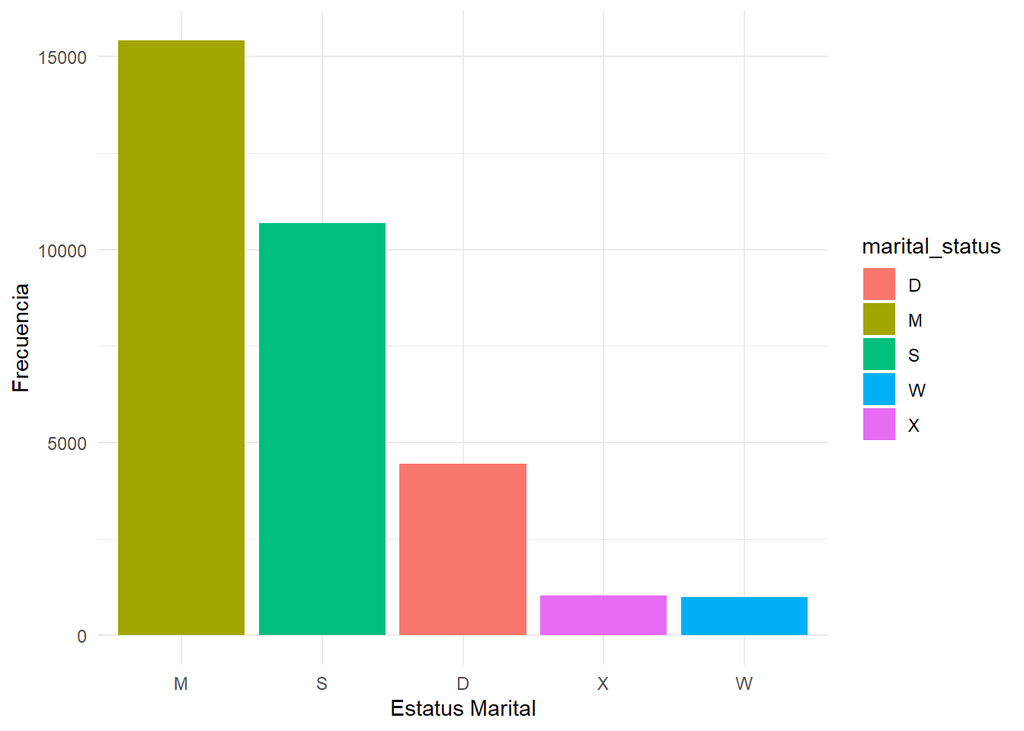

```r
dataFrame  %>%
  ggplot(aes(x =  fct_infreq(marital_status), fill = marital_status)) +
  geom_bar(show.legend = TRUE) + theme_minimal() +
  ylab("Frecuencia") +
  xlab("Estatus Marital")
```

## 4.3 Género

Revisamos los valores

```r
unique(dataFrame$gender)
```

```
## [1] "M"      "Fem"    "m"      "F"      "male"   "female" "Male"   "Female"
```

Realizamos los reemplazos

```r
dataFrame$gender[dataFrame$gender == 'M'] <- "m"
dataFrame$gender[dataFrame$gender == 'Fem'] <- "f"
dataFrame$gender[dataFrame$gender == 'F'] <- "f"
dataFrame$gender[dataFrame$gender == 'male'] <- "m"
dataFrame$gender[dataFrame$gender == 'female'] <- "f"
dataFrame$gender[dataFrame$gender == 'Male'] <- "m"
dataFrame$gender[dataFrame$gender == 'Female'] <- "f"


unique(dataFrame$gender)
```

```
## [1] "m" "f"
```

Graficamos la distribución de la variable:

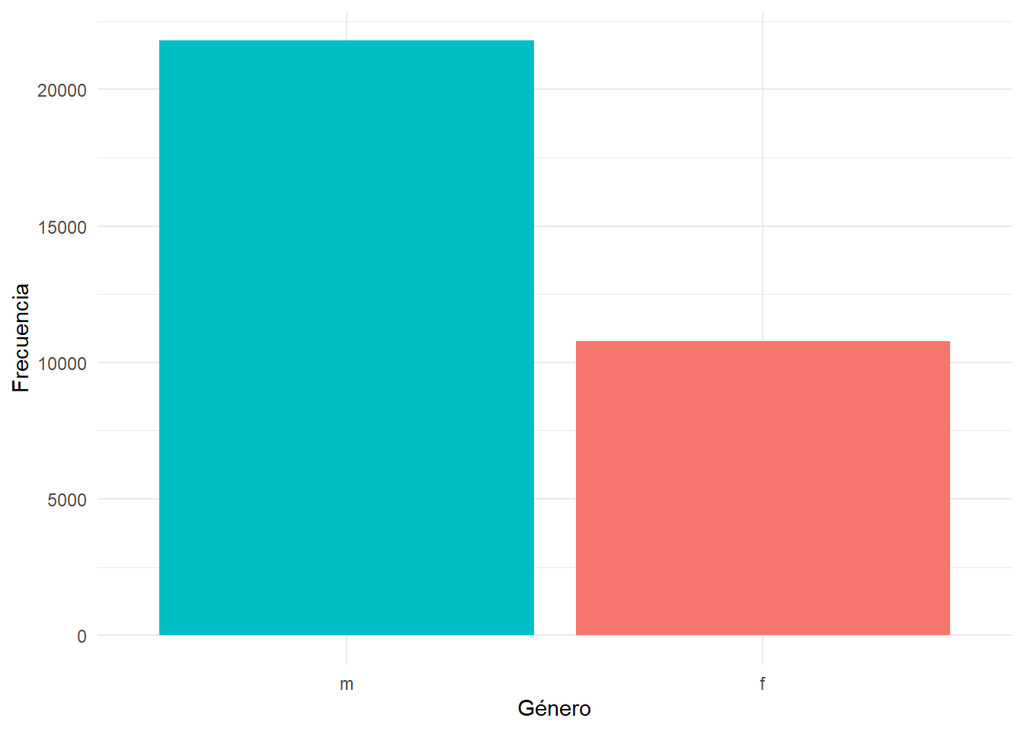

```r
dataFrame  %>%
  ggplot(aes(x =  fct_infreq(gender), fill = gender)) +
  geom_bar(show.legend = FALSE) + theme_minimal() +
  ylab("Frecuencia") +
  xlab("Género")
```

# 5.Normalización de los datos cuantitativos

## 5.1 Edad

```r
dataFrame$age <- as.integer(dataFrame$age)
head(dataFrame$age)
```

```
## [1] 50 38 53 28 37 49
```

## 5.2 Educación

```r
dataFrame$education_num <- as.integer(dataFrame$education_num)
head(dataFrame$education_num)
```

```
## [1] 13  9  7 13 14  5
```

## 5.3 Horas por Semana

Observamos que la variable contiene carácteres

```r
head(unique(dataFrame$hours_per_week))
```

```
## [1] "13,5 h" "40 h"   "40,5 h" "16 h"   "45 h"   "50,5 h"
```

```r
dataFrame$hours_per_week <- gsub(",", ".", dataFrame$hours_per_week)
dataFrame$hours_per_week <- gsub("h", "", dataFrame$hours_per_week)
dataFrame$hours_per_week <- as.numeric(dataFrame$hours_per_week)

head(dataFrame$hours_per_week)
```

```
## [1] 13.5 40.0 40.5 40.0 40.5 16.0
```

## 5.4 Income

Observamos que tenemos valores en dos escalas diferentes: Miles de euros y euros

```r
head(unique(dataFrame$income),30)
```

```
##  [1] "2000,3 Milers d'euros" "51,67 Milers d'euros"  "50,08 Milers d'euros"
##  [4] "44,21 Milers d'euros"  "0,1 Milers d'euros"    "43,93 Milers d'euros"
##  [7] "2134,6 Milers d'euros" "38,24 Milers d'euros"  "57,12 Milers d'euros"
## [10] "49,72 Milers d'euros"  "51,08 Milers d'euros"  "44,34 Milers d'euros"
## [13] "41,98 Milers d'euros"  "46,53 Milers d'euros"  "42,5 Milers d'euros"
## [16] "51,16 Milers d'euros"  "51,95 Milers d'euros"  "47,88 Milers d'euros"
## [19] "44,38 Milers d'euros"  "55,01 Milers d'euros"  "35,87 Milers d'euros"
## [22] "49,36 Milers d'euros"  "52610 euros"           "38,3 Milers d'euros"
## [25] "56,66 Milers d'euros"  "47,19 Milers d'euros"  "42,7 Milers d'euros"
## [28] "55,67 Milers d'euros"  "53,18 Milers d'euros"  "55,48 Milers d'euros"
```

Tratamos de diferenciar al máximo los registros de ambas escalas:

```r
dataFrame$income <- gsub(" d'euros", "",dataFrame$income)
head(dataFrame$income, 30)
```

```
##  [1] "2000,3 Milers" "51,67 Milers"  "50,08 Milers"  "44,21 Milers"
##  [5] "0,1 Milers"    "43,93 Milers"  "2134,6 Milers" "38,24 Milers"
##  [9] "57,12 Milers"  "49,72 Milers"  "51,08 Milers"  "44,34 Milers"
## [13] "41,98 Milers"  "46,53 Milers"  "42,5 Milers"   "51,16 Milers"
## [17] "51,95 Milers"  "47,88 Milers"  "44,38 Milers"  "55,01 Milers"
## [21] "35,87 Milers"  "49,36 Milers"  "52610 euros"   "38,3 Milers"
## [25] "56,66 Milers"  "47,19 Milers"  "42,7 Milers"   "55,67 Milers"
## [29] "53,18 Milers"  "55,48 Milers"
```

```r
#Dividimos el dataset filtrando para realizar la limpieza
data_1 <- dataFrame %>%
  filter(grepl("euros$", income))

dim(data_1)
```

```
## [1] 999  12
```

```r
data_2 <- dataFrame %>%
  filter(grepl("Milers$", income))


dim(data_2)
```

```
## [1] 31554    12
```

```r
dim(dataFrame)
```

```
## [1] 32553    12
```

Divimos entre 1000 para tener la misma escala de medida, antes limpiamos de carácteres la variable

```r
data_1$income <- as.numeric(gsub(" euros$", "", data_1$income)) / 1000

head(data_1$income)
```

```
## [1] 52.61 50.43 49.56 57.12 52.15 40.60
```

Observamos que los cambios se han ejecutado correctamente, trabajando sobre la escala de la correspondiente parte del dataset

Ejecutamos la limpieza en la otra parte del dataset original.

```r
data_2$income <- as.numeric(gsub(",",".",gsub(" Milers$", "", data_2$income)))
head(data_2$income)
```

```
## [1] 2000.30   51.67   50.08   44.21    0.10   43.93
```

Juntamos las dos partes

```r
dataFrameNew <- rbind(data_1, data_2)
head(dataFrameNew)
```

```
##   age     workclass education_num marital_status  relationship   occupation
## 1  43       Private             7              M       Husband  Blue-Collar
## 2  53 Self-Employed            13              M       Husband Professional
## 3  35       Private            11              M       Husband      Service
## 4  49    Government             9              M     Own-child      Service
## 5  55       Private            10              M       Husband        Sales
## 6  24       Private             9              S Not-in-family      Service
##    race gender hours_per_week income education_cat   CS_ID
## 1 White      m           40.5  52.61      Primaria CS32583
## 2 White      m           40.5  50.43 Universitaria CS32601
## 3 White      m           40.5  49.56 Universitaria CS32617
## 4 White      m           40.0  57.12    Secundario CS32646
## 5 White      m           56.0  52.15 Universitaria CS32678
## 6 White      f           40.0  40.60    Secundario CS32691
```

```r
sapply(dataFrameNew, mode)
```

```
##            age      workclass  education_num marital_status   relationship
##      "numeric"    "character"      "numeric"    "character"    "character"
##     occupation           race         gender hours_per_week         income
##    "character"    "character"    "character"      "numeric"      "numeric"
##  education_cat          CS_ID
##    "character"    "character"
```

# 6.Valores Atípicos

## Age

Observamos valores atípicos en la variable Age.

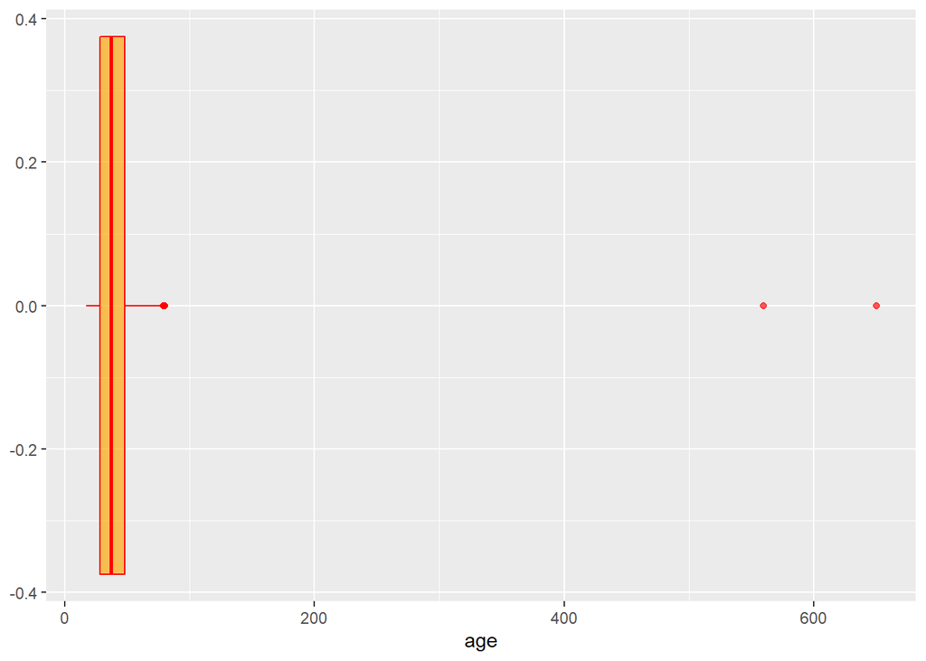

```r
dataFrameNew %>%
  ggplot(aes(x = age, )) +
  geom_boxplot(alpha = 0.65, show.legend = F, color="red", fill="orange")
```

Tenemos dos valores imposibles: 650 y 560

```r
dataFrameNew$age[dataFrameNew$age > 99]
```

```
## [1] 650 560
```

Sustituimos por NA

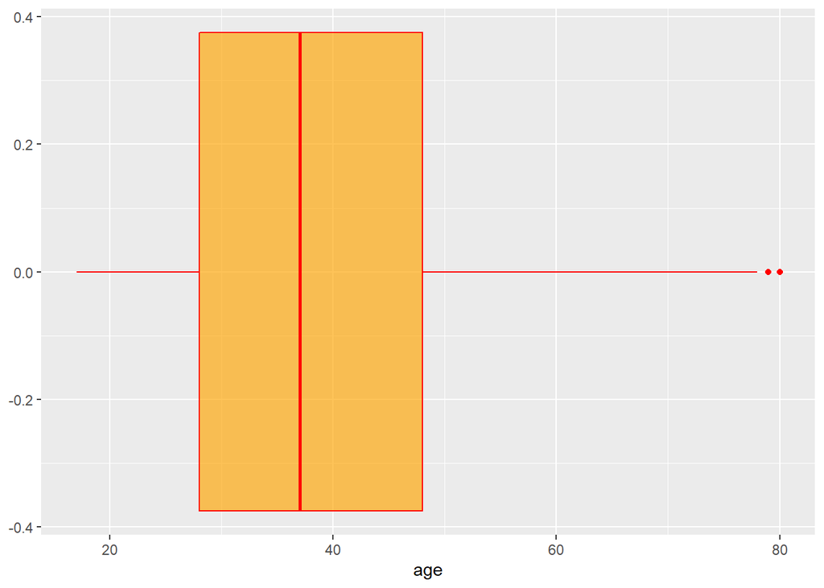

```r
dataFrameNew$age[dataFrameNew$age > 99] <- NA

dataFrameNew %>%
  ggplot(aes(x = age, )) +
  geom_boxplot(alpha = 0.65, show.legend = F, color="red", fill="orange")
```

## education_num

En este caso hay menor claridad; por lo tanto procedemos a calcular el RIC y multiplicarlo por 1.5. Con este cálculo podemos determinar valores atípicos, sumándolo o restándolo al los cuartiles 25 y 75 (Vegas-Lozano).

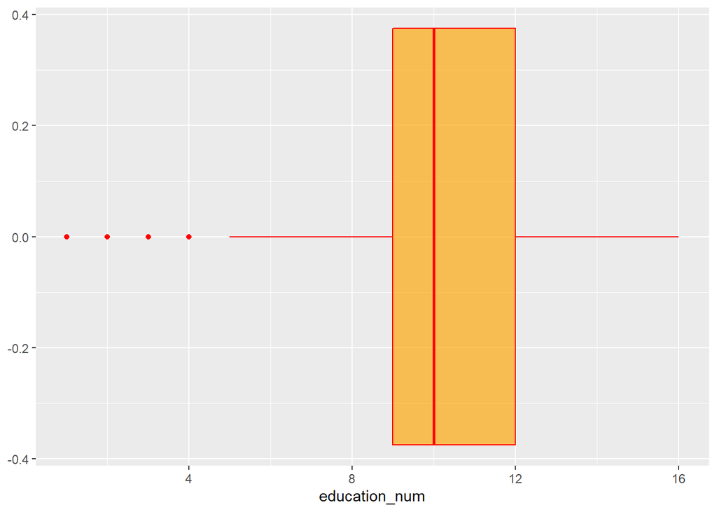

```r
dataFrameNew %>%
  ggplot(aes(x = education_num, )) +
  geom_boxplot(alpha = 0.65, show.legend = F, color="red", fill="orange")
```

Calculamos los cuartiles

```r
summary(dataFrameNew$education_num)
```

```
##    Min. 1st Qu.  Median    Mean 3rd Qu.    Max.
##    1.00    9.00   10.00   10.08   12.00   16.00
```

Calculamos el rango y lo multiplicamos por 1.5

```r
r <- (12 - 9) * 1.5
```

Reemplazamos por NA

```r
inferior = 9 - r
superior = 12 + r
dataFrameNew$education_num[dataFrameNew$education_num<inferior] <- NA
dataFrameNew$education_num[dataFrameNew$education_num>superior] <- NA
```

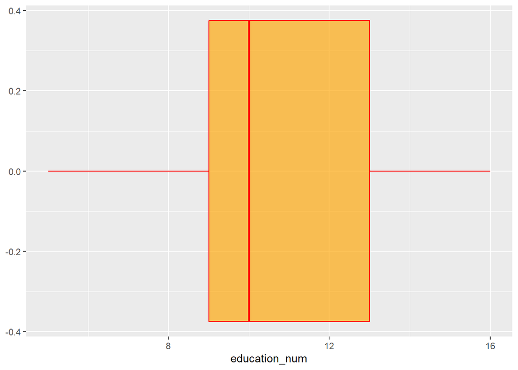

```r
dataFrameNew %>%
  ggplot(aes(x = education_num, )) +
  geom_boxplot(alpha = 0.65, show.legend = F, color="red", fill="orange")
```

## hours_per_week

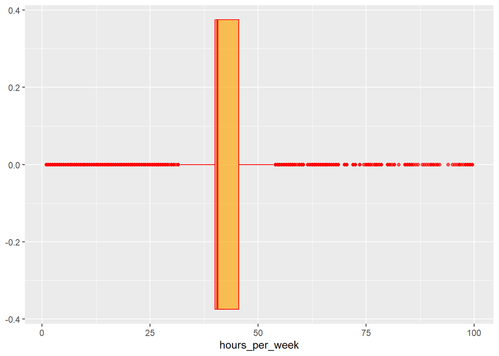

```r
dataFrameNew %>%
  ggplot(aes(x = hours_per_week, )) +
  geom_boxplot(alpha = 0.65, show.legend = F, color="red", fill="orange")
```

```r
diff(quantile(x = dataFrameNew$hours_per_week, probs = c(0.25,0.75))) * 1.5
```

```
##  75%
## 8.25
```

```r
summary(dataFrameNew$hours_per_week)
```

```
##    Min. 1st Qu.  Median    Mean 3rd Qu.    Max.
##    1.00   40.00   40.50   40.71   45.50   99.50
```

Si tomamos el criterio de la multiplicación del RIC por 1.5, para el caso de la variable hours_per_week estaríamos reemplazando cerca de un 26% de los datos por NA. Debido a que este porcentaje es muy alto se decide utilizar otro criterio para detectar y reemplazar los datos atípicos

```r
inferior = 40.0 - 8.25

superior = 45.50 + 8.25

length(dataFrameNew$hours_per_week[dataFrameNew$hours_per_week<inferior])
```

```
## [1] 5249
```

```r
length(dataFrameNew$hours_per_week[dataFrameNew$hours_per_week>superior])
```

```
## [1] 3466
```

```r
x<-boxplot.stats(dataFrameNew$hours_per_week)$out
length(x)
```

```
## [1] 8715
```

uitlizando las propiedades de la función boxplot, nos da que tenemos que reemplazar 8715 casos, dividir eso entre el número total de filas nos da casi 27% de la data para reemplazar:

```r
dim(dataFrameNew)
```

```
## [1] 32553    12
```

```r
(8715/32553) * 100
```

```
## [1] 26.77173
```

El otro criterio planteado es reemplazar por NA los valores que se encuentren a 2.5 desviaciones típicas con respecto a la media. Esto nos da como resultados unos limites razonables; de esta forma no tendremos registros de personas que trabajen menos de 9hs por semana o más de 72hs y tampoco reemplazaremos por NA un porcentaje alto de la muestra.

```r
inferior = mean(dataFrameNew$hours_per_week) - (sd(dataFrameNew$hours_per_week)*2.5)

superior = mean(dataFrameNew$hours_per_week) + (sd(dataFrameNew$hours_per_week)*2.5)

print(length(dataFrameNew$hours_per_week[dataFrameNew$hours_per_week<inferior]))
```

```
## [1] 458
```

```r
print(length(dataFrameNew$hours_per_week[dataFrameNew$hours_per_week>superior]))
```

```
## [1] 498
```

```r
dataFrameNew$hours_per_week[dataFrameNew$hours_per_week<inferior] <- NA
dataFrameNew$hours_per_week[dataFrameNew$hours_per_week>superior] <- NA
```

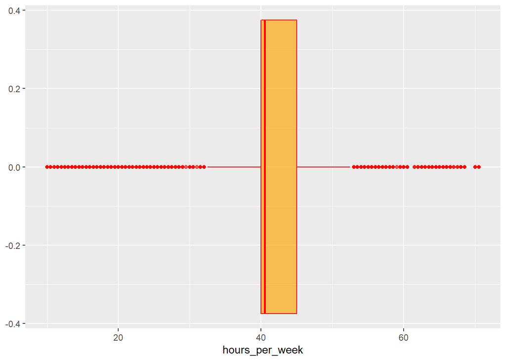

```r
dataFrameNew %>%
  ggplot(aes(x = hours_per_week, )) +
  geom_boxplot(alpha = 0.65, show.legend = F, color="red", fill="orange")
```

## income

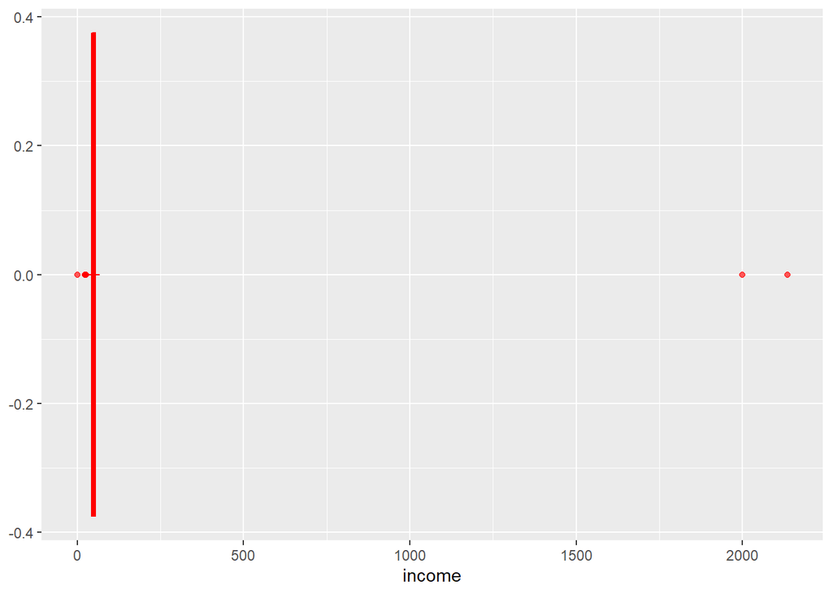

```r
dataFrameNew %>%
  ggplot(aes(x = income, )) +
  geom_boxplot(alpha = 0.65, show.legend = F, color="red", fill="orange")
```

```r
x<-boxplot.stats(dataFrameNew$income)$out
length(x)
```

```
## [1] 8
```

```r
x
```

```
## [1] 2000.30    0.10 2134.60   22.54   25.71   25.06   26.04   25.69
```

Reemplazamos por NA los valores atípicos de Income

```r
dataFrameNew$income[dataFrameNew$income<26.04] <- NA
dataFrameNew$income[dataFrameNew$income>2000] <- NA
```

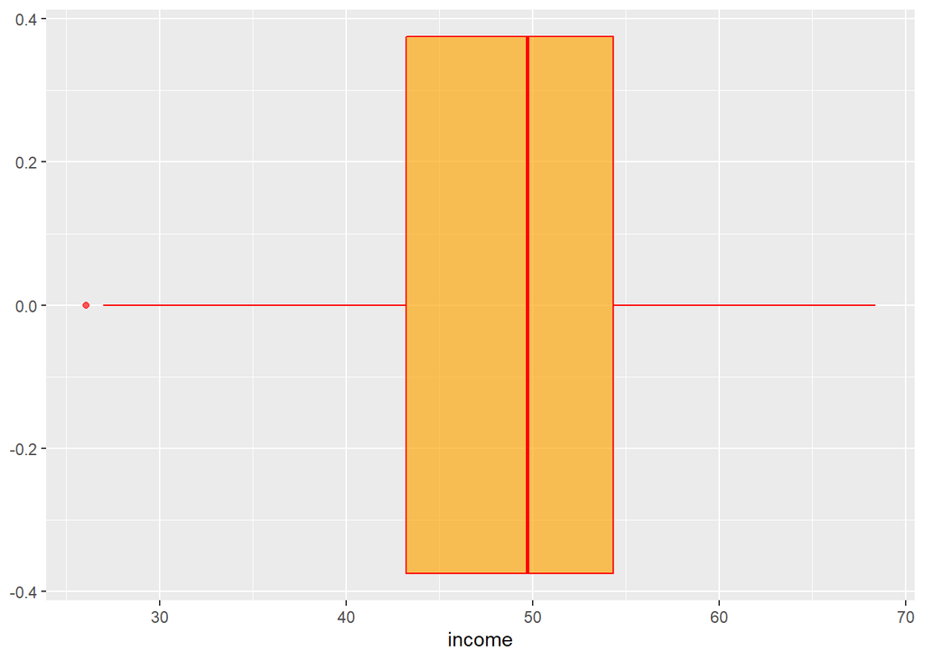

```r
dataFrameNew %>%
  ggplot(aes(x = income, )) +
  geom_boxplot(alpha = 0.65, show.legend = F, color="red", fill="orange")
```

# 7.Imputación de valores

Contamos los valores perdidos de Age

```r
sum(is.na(dataFrameNew$age))
```

```
## [1] 2
```

Realizamos el reemplazo por la media

```r
dataFrameNew$age[is.na(dataFrameNew$age)] <- mean(dataFrameNew$age, na.rm = TRUE)
```

```r
sum(is.na(dataFrameNew$age))
```

```
## [1] 0
```

Income

Observamos un promedio mayor en el income de los hombres con respecto a las mujeres

```r
dataFrameNew %>%
  group_by(gender) %>%
  summarise(n = n(),
            Mean = mean(income, na.rm =TRUE))
```

```
## # A tibble: 2 x 3
##   gender     n  Mean
##   <chr>  <int> <dbl>
## 1 f      10767  41.5
## 2 m      21786  52.3
```

```r
female <- dataFrameNew %>% filter(gender == 'f')
sum(is.na(female$income))
```

```
## [1] 5
```

```r
male <- dataFrameNew %>% filter(gender == 'm')
sum(is.na(male$income))
```

```
## [1] 2
```

Realizamos los reemplazos

```r
female$income[is.na(female$income)] <- mean(female$income, na.rm = TRUE)
sum(is.na(female$income))
```

```
## [1] 0
```

```r
male$income[is.na(male$income)] <- mean(male$income, na.rm = TRUE)
sum(is.na(male$income))
```

```
## [1] 0
```

```r
dataFrameNew <- rbind(female, male)
sum(is.na(dataFrameNew$income))
```

```
## [1] 0
```

Hacemos de nuevo split del dataset, esta vez para reemplazar los valores ausentes de las variables education_num & hours_per_week. Separamos para correr el algoritmo del KNN vecinos solo en hombres y mujeres y realizar las imputaciones con base a los registros más parecidos

```r
female <- dataFrameNew %>% filter(gender == 'f')
male <- dataFrameNew %>% filter(gender == 'm')
```

Tenemos 305 valores perdidos en education_num en la parte del dataset correspondiente a las mujeres

```r
sum(is.na(female$education_num))
```

```
## [1] 305
```

317 en el caso de las horas de trabajo.

```r
sum(is.na(female$hours_per_week))
```

```
## [1] 317
```

Seleccionamos las variables relevantes para la imputación

```r
vars = c('age','income','education_num','hours_per_week')
```

Corremos el algoritmo de vecinos cercanos para reemplazar los valores **NA** de las variables **education_num** y **hours_per_week** a partir de las variables cuantitativas del dataset

```r
outputFemale <- kNN(female[,vars], variable = c('education_num','hours_per_week'), k =11)
```

Agregamos los campos al dataset de las mujeres, adicionalmente tendremos dos variables booleanas que nos permiten saber cuáles registros han tenido alguna imputación.

```r
female[,c('education_num','hours_per_week',
           'education_num_imp','hours_per_week_imp')] <- outputFemale[,c('education_num','hours_per_week',
                                                                         'education_num_imp','hours_per_week_imp')]
```

Comprobamos que no hay NA

```r
sum(is.na(female$education_num))
```

```
## [1] 0
```

```r
sum(is.na(female$hours_per_week))
```

```
## [1] 0
```

Mostramos algunos de los casos con han tenido imputación en el dataset de las mujeres:

```r
head(female[female$education_num_imp==TRUE | female$hours_per_week_imp==TRUE ,])
```

```
##     age     workclass education_num marital_status  relationship    occupation
## 66   64 Other/Unknown            10              W       Husband Other/Unknown
## 109  58    Government             9              D       Husband       Service
## 115  70 Other/Unknown             9              W          Wife Other/Unknown
## 141  32 Self-Employed             9              M     Own-child       Service
## 171  35 Self-Employed             7              D Not-in-family  White-Collar
## 179  43       Private            10              D Not-in-family       Service
##      race gender hours_per_week income education_cat   CS_ID education_num_imp
## 66  White      f           40.5  40.36      Primaria CS38120              TRUE
## 109 Black      f           40.5  37.30      Primaria CS42149              TRUE
## 115 White      f           32.0  38.18    Secundario CS43269             FALSE
## 141 White      f           40.0  33.29    Secundario CS46749             FALSE
## 171 White      f           40.0  43.15      Primaria CS49994             FALSE
## 179 White      f           40.5  38.59      Primaria CS50364              TRUE
##     hours_per_week_imp
## 66               FALSE
## 109              FALSE
## 115               TRUE
## 141               TRUE
## 171               TRUE
## 179              FALSE
```

```r
head(female[c("education_num", "hours_per_week")][female$education_num_imp==TRUE | female$hours_per_week_imp==TRUE ,])
```

```
##     education_num hours_per_week
## 66             10           40.5
## 109             9           40.5
## 115             9           32.0
## 141             9           40.0
## 171             7           40.0
## 179            10           40.5
```

```r
tail(female[c("education_num", "hours_per_week")][female$education_num_imp==TRUE | female$hours_per_week_imp==TRUE ,])
```

```
##       education_num hours_per_week
## 10707             9           40.5
## 10717            10           35.5
## 10721            10           48.5
## 10731            16           40.5
## 10750            11           30.5
## 10754            13           40.5
```

Ahora realizamos el mismo procedimiento en el dataset de los hombres:

```r
outputMale <- kNN(male[,vars], variable = c('education_num','hours_per_week'), k =11)
```

```r
male[,c('education_num','hours_per_week',
           'education_num_imp','hours_per_week_imp')] <- outputMale[,c('education_num','hours_per_week',
                                                                         'education_num_imp','hours_per_week_imp')]
```

Comprobamos que no hay NA

```r
sum(is.na(male$education_num))
```

```
## [1] 0
```

```r
sum(is.na(male$hours_per_week))
```

```
## [1] 0
```

Observamos los registros que han sufrido imputaciones:

```r
head(male[c("education_num", "hours_per_week")][male$education_num_imp==TRUE | male$hours_per_week_imp==TRUE ,])
```

```
##    education_num hours_per_week
## 7              9           40.5
## 28             9           40.0
## 38            10           40.5
## 43            10           40.0
## 59            10           40.5
## 60             9           60.5
```

```r
tail(male[c("education_num", "hours_per_week")][male$education_num_imp==TRUE | male$hours_per_week_imp==TRUE ,])
```

```
##       education_num hours_per_week
## 21705             9           56.0
## 21706            10           40.5
## 21718             9           40.5
## 21727            13           40.5
## 21738             8           40.5
## 21748             9           20.0
```

Concatenamos de nuevo los dos datasets, para obtener el original con las modificaciones pertinentes

```r
dataFinal <- rbind(female, male)
head(dataFinal,2)
```

```
##   age workclass education_num marital_status  relationship occupation  race
## 1  24   Private             9              S Not-in-family    Service White
## 2  27   Private            10              S       Husband      Sales White
##   gender hours_per_week income education_cat   CS_ID education_num_imp
## 1      f             40  40.60    Secundario CS32691             FALSE
## 2      f             40  39.51 Universitaria CS32701             FALSE
##   hours_per_week_imp
## 1              FALSE
## 2              FALSE
```

# 8.Estudio descriptivo

## 8.1 Funciones de media robustas

Implementamos la función de la media recortada:

```r
media.recortada <- function(x, perc=0.05){

  if(length(perc) != 1 || perc < 0 || perc > 1) {
    stop("bad value for 'Trim'")
  }
  perc = perc
  qSuperior <- quantile(x, prob = (1-perc))[[1]]
  qInferior <- quantile(x, prob = perc)[[1]]

  x[x>qSuperior] <- NA
  x[x<qInferior] <- NA
  mean <- mean(x, na.rm=TRUE)

  return(mean)

}
```

Es importante que el usuario entienda que el argumento perc se aplica para cada cola de la distribución. No se devide entre dos para luego recortar dentro de la función.

Comprobamos

```r
media.recortada(dataFinal$age, 0.05)
```

```
## [1] 37.63105
```

```r
mean(dataFinal$age, trim = 0.05)
```

```
## [1] 37.99113
```

Obtenemos valores cercanos.

Ahora implementamos la función correspondiente al cálculo de media Winsor.

```r
media.winsor <- function(x, perc=0.05){

  if(length(perc) != 1 || perc < 0 || perc > 1) {
    stop("bad value for 'Winzoring'")}


  qSuperior <- quantile(x, prob = (1-perc))[[1]]
  qInferior <- quantile(x, prob = perc)[[1]]

  x[x>qSuperior] <- qSuperior
  x[x<qInferior] <- qInferior


  return(mean(x))
}
```

Para realizar las comprobaciones, utilizamos el paquete **psych**

```r
#install.packages("psych")
library(psych)
winsor.mean(dataFinal$age, trim = 0.05)
```

```
## [1] 38.2919
```

```r
media.winsor(dataFinal$age, perc = 0.05)
```

```
## [1] 38.2919
```

Obtenemos el mismo valor. Procedemos a realizar el análisis descriptivo

## 8.2 Estudio descriptivo de las variables cuantitativas

### Age

Medidas de tendencia central

```r
summary(dataFinal$age)
```

```
##    Min. 1st Qu.  Median    Mean 3rd Qu.    Max.
##   17.00   28.00   37.00   38.55   48.00   80.00
```

```r
medidasTendenciaCentral = c(round(mean(dataFinal$age),2),
                            round(media.recortada(dataFinal$age, perc = 0.05),2),
                            round(media.winsor(dataFinal$age, perc = 0.05),2),
                            round(median(dataFinal$age),2))

etiquetasTendenciaCentral = c("Promedio", "Promedio Recortado", "Promedio Winsor","Mediana")
```

Todas las medidas de tendencia central son cercanas entre sí para la variable Age

```r
tibble(etiquetasTendenciaCentral, medidasTendenciaCentral)
```

```
## # A tibble: 4 x 2
##   etiquetasTendenciaCentral medidasTendenciaCentral
##   <chr>                                       <dbl>
## 1 Promedio                                     38.6
## 2 Promedio Recortado                           37.6
## 3 Promedio Winsor                              38.3
## 4 Mediana                                      37
```

```r
t.test(x=dataFinal$age, conf.level=0.95)$conf.int
```

```
## [1] 38.40274 38.69695
## attr(,"conf.level")
## [1] 0.95
```

Medidas de dispersión

Tanto la desviación estándar como la winsor se encuentran cercanas entre sí. El preprocesamiento ha sido correcto eliminando los valores centinela o irreales que teníamos en esta distribución.

```r
medidasDisper <- c(round(sd(dataFinal$age),2),
                   round(winsor.sd(dataFinal$age, trim = 0.05),2)
                   )

etiquetasDisper <- c("Desviación Estándar", "Desviación Winsor")

tibble(etiquetasDisper, medidasDisper)
```

```
## # A tibble: 2 x 2
##   etiquetasDisper     medidasDisper
##   <chr>                       <dbl>
## 1 Desviación Estándar          13.5
## 2 Desviación Winsor            12.8
```

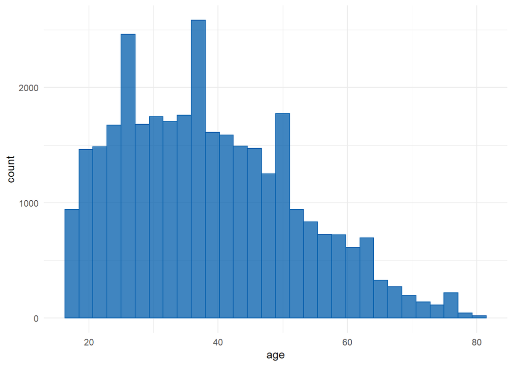

```r
dataFinal %>%
  ggplot(aes(x = age)) +
  geom_histogram(alpha = 0.75, show.legend = F,  color = "#005CAB", fill = "#005CAB") +
  theme_minimal()
```

Comparamos con el género

Las distribuciones se comportan igual, hay mayor cantidad de registros de género masculino.

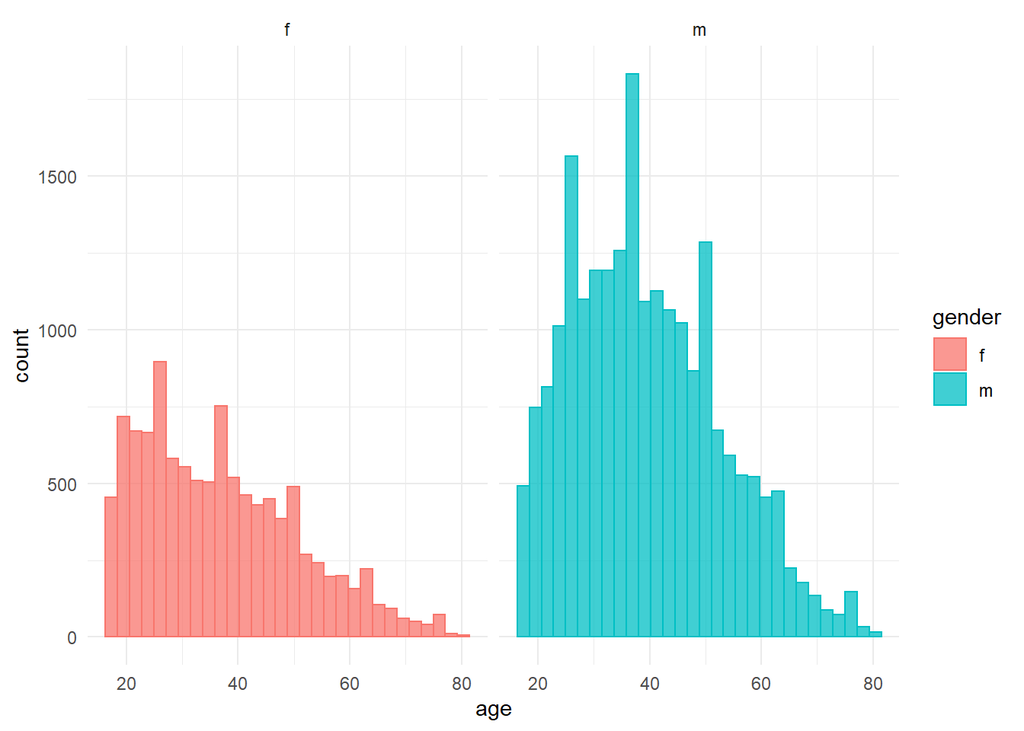

```r
dataFinal %>%
  ggplot(aes(x = age, color = gender, fill = gender)) + facet_wrap(~gender) +
  geom_histogram(alpha = 0.75, show.legend = T) +
  theme_minimal()
```

Observamos también una mayor cantidad de personas de raza blanca en la muestra.

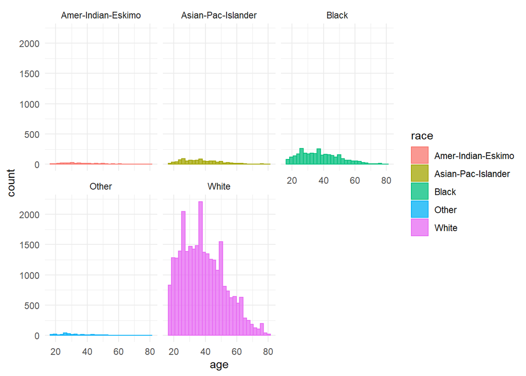

```r
dataFinal %>%
  ggplot(aes(x = age, color = race, fill = race)) + facet_wrap(~race) +
  geom_histogram(alpha = 0.75, show.legend = T) +
  theme_minimal()
```

La distrución de la edad de personas solteras se encuentra sesgada a la izquierda

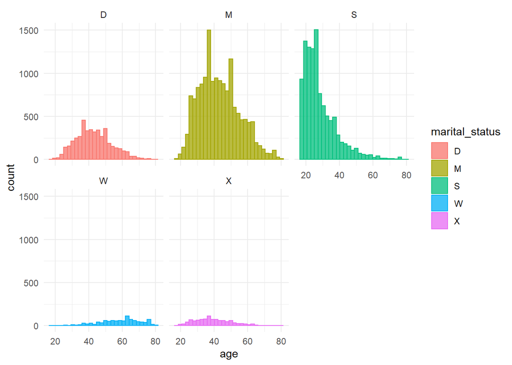

```r
dataFinal %>%
  ggplot(aes(x = age, color = marital_status, fill = marital_status)) + facet_wrap(~marital_status) +
  geom_histogram(alpha = 0.75, show.legend = T) +
  theme_minimal()
```

### education_num

```r
summary(dataFinal$education_num)
```

```
##    Min. 1st Qu.  Median    Mean 3rd Qu.    Max.
##    5.00    9.00   10.00   10.31   12.00   16.00
```

```r
medidasTendenciaCentral = c(round(mean(dataFinal$education_num),2),
                            round(media.recortada(dataFinal$education_num, perc = 0.05),2),
                            round(media.winsor(dataFinal$education_num, perc = 0.05),2),
                            round(median(dataFinal$education_num),2))

etiquetasTendenciaCentral = c("Promedio", "Promedio Recortado", "Promedio Winsor","Mediana")
```

Todas las medidas de tendencia central son cercanas entre sí.

```r
tibble(etiquetasTendenciaCentral, medidasTendenciaCentral)
```

```
## # A tibble: 4 x 2
##   etiquetasTendenciaCentral medidasTendenciaCentral
##   <chr>                                       <dbl>
## 1 Promedio                                     10.3
## 2 Promedio Recortado                           10.4
## 3 Promedio Winsor                              10.3
## 4 Mediana                                      10
```

El intervalo de confianza de la media de años de educación al 95% se encuentra entre 10.28 y 10.33

```r
t.test(x=dataFinal$education_num, conf.level=0.95)$conf.int
```

```
## [1] 10.28908 10.33716
## attr(,"conf.level")
## [1] 0.95
```

Notamos baja dispersión en los datos. Las medidas de dispersión son cercanas entre sí.

```r
medidasDisper <- c(round(sd(dataFinal$education_num),2),
                   round(winsor.sd(dataFinal$education_num, trim = 0.05),2)
                   )

etiquetasDisper <- c("Desviación Estándar", "Desviación Winsor")

tibble(etiquetasDisper, medidasDisper)
```

```
## # A tibble: 2 x 2
##   etiquetasDisper     medidasDisper
##   <chr>                       <dbl>
## 1 Desviación Estándar          2.21
## 2 Desviación Winsor            2.01
```

La mayoría de los casos se encuentra en torno a los 8 y 11 años de educación.

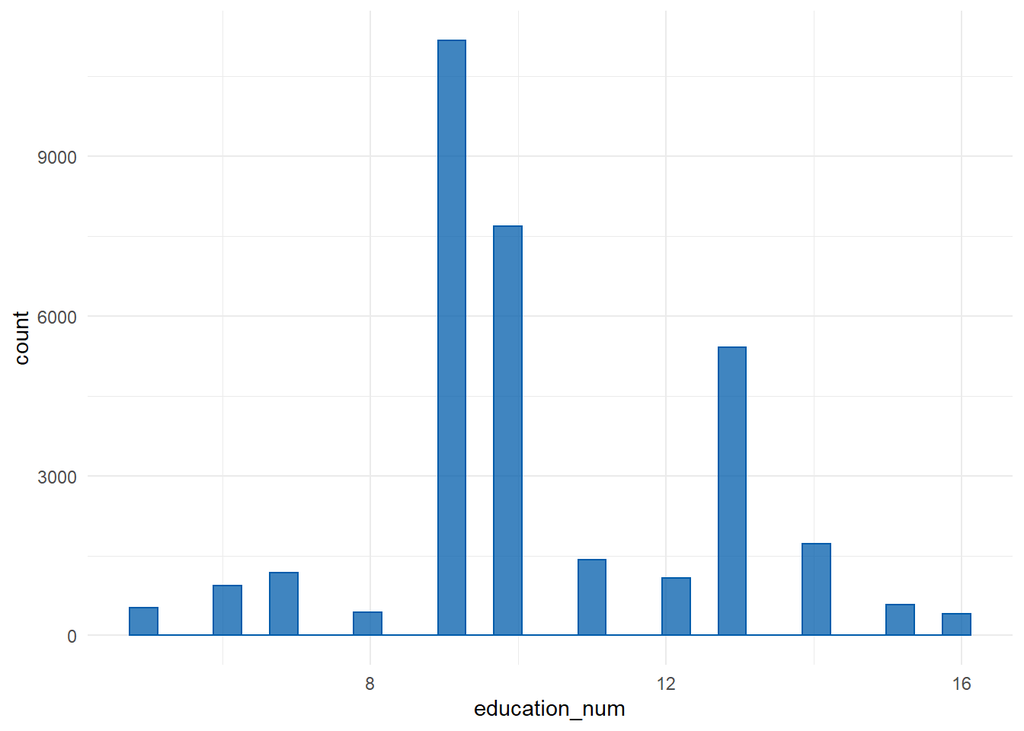

```r
dataFinal %>%
  ggplot(aes(x = education_num)) +
  geom_histogram(alpha = 0.75, show.legend = F,  color = "#005CAB", fill = "#005CAB") +
  theme_minimal()
```

Distribucines de años de educación similares entre hombres y mujeres.

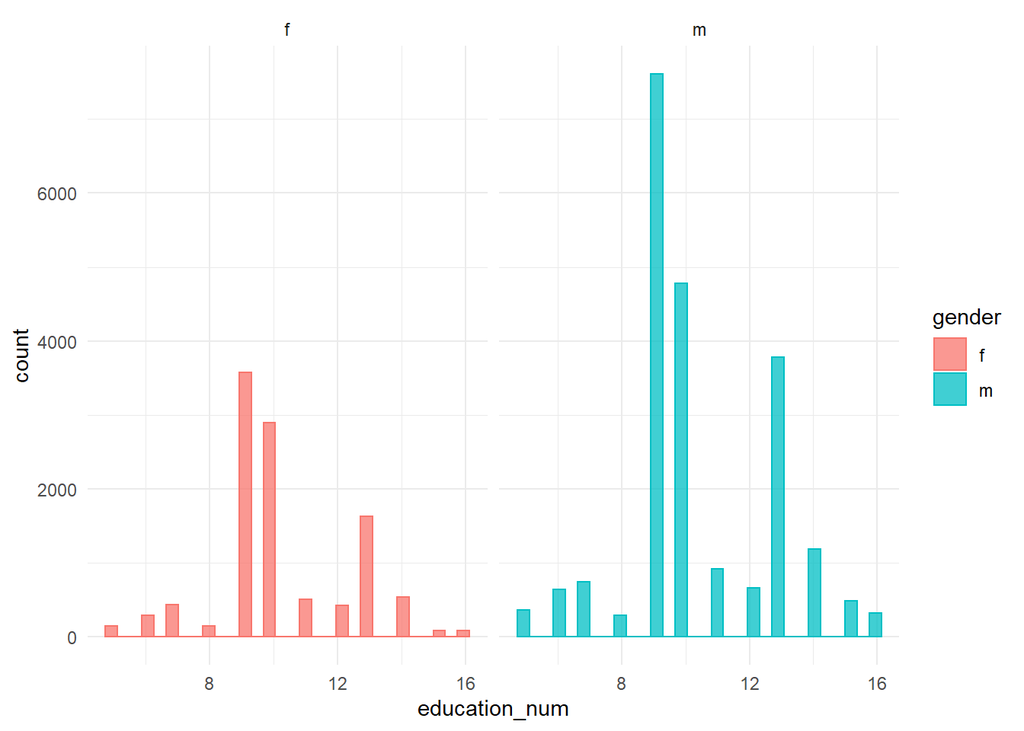

```r
dataFinal %>%
  ggplot(aes(x = education_num, color = gender, fill = gender)) + facet_wrap(~gender) +
  geom_histogram(alpha = 0.75, show.legend = T) +
  theme_minimal()
```

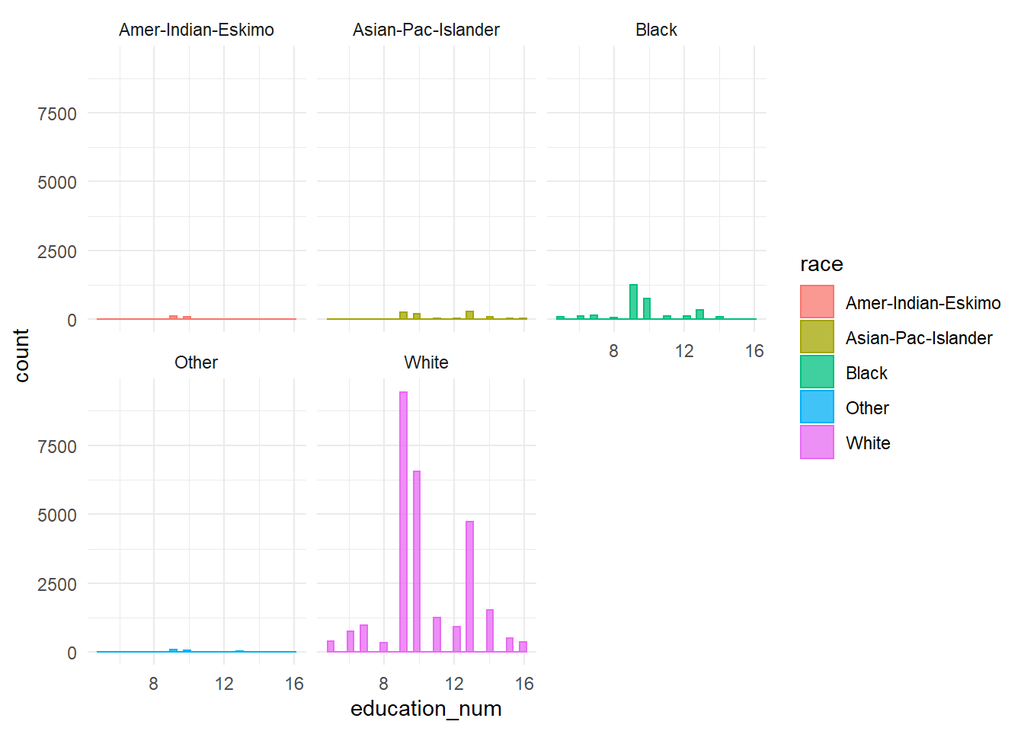

```r
dataFinal %>%
  ggplot(aes(x = education_num, color = race, fill = race)) + facet_wrap(~race) +
  geom_histogram(alpha = 0.75, show.legend = T) +
  theme_minimal()
```

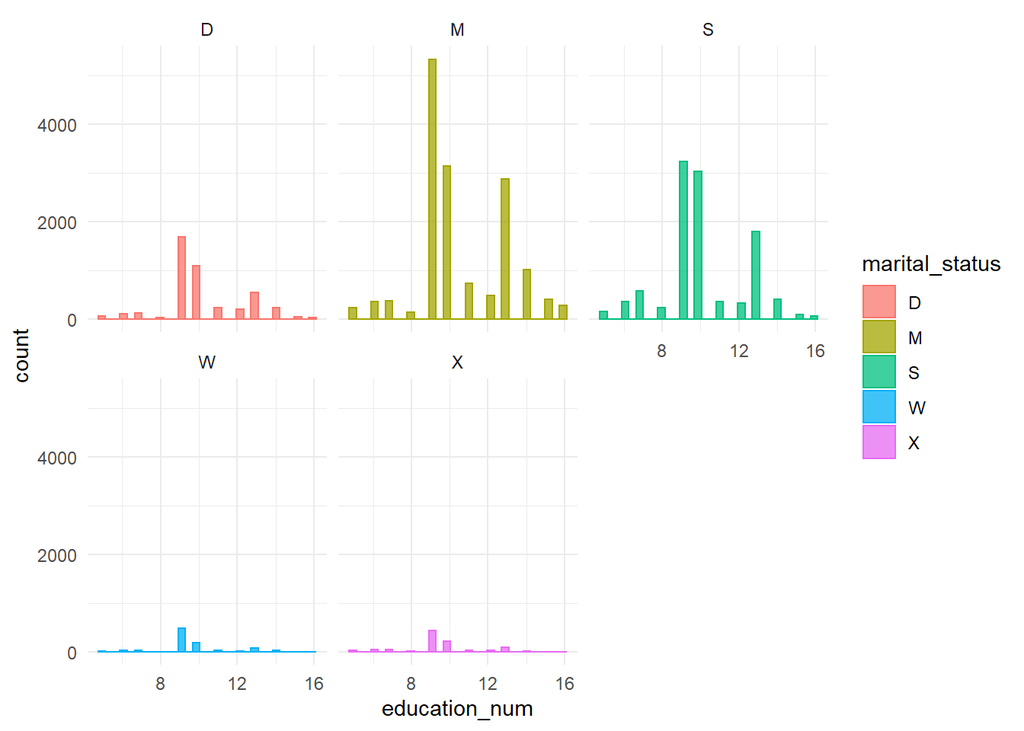

```r
dataFinal %>%
  ggplot(aes(x = education_num, color = marital_status, fill = marital_status)) + facet_wrap(~marital_status) +
  geom_histogram(alpha = 0.75, show.legend = T) +
  theme_minimal()
```

### hours_per_week

```r
summary(dataFinal$hours_per_week)
```

```
##    Min. 1st Qu.  Median    Mean 3rd Qu.    Max.
##   10.00   40.00   40.50   40.47   45.00   70.50
```

```r
medidasTendenciaCentral = c(round(mean(dataFinal$hours_per_week),2),
                            round(media.recortada(dataFinal$hours_per_week, perc = 0.05),2),
                            round(media.winsor(dataFinal$hours_per_week, perc = 0.05),2),
                            round(median(dataFinal$hours_per_week),2))

etiquetasTendenciaCentral = c("Promedio", "Promedio Recortado", "Promedio Winsor","Mediana")
```

En el caso de las horas trabajadas a la semana, tenemos estadísticos de tendencia central cercanos entre sí y correspondientes a una jornada laboral de tiempo comentro de 40 horas a la semana.

```r
tibble(etiquetasTendenciaCentral, medidasTendenciaCentral)
```

```
## # A tibble: 4 x 2
##   etiquetasTendenciaCentral medidasTendenciaCentral
##   <chr>                                       <dbl>
## 1 Promedio                                     40.5
## 2 Promedio Recortado                           40.5
## 3 Promedio Winsor                              40.5
## 4 Mediana                                      40.5
```

La variable tiene un intervalo de confianza al 95% de entre 40.35 y 40.58 horas trabajadas a la semana.

```r
t.test(x=dataFinal$hours_per_week, conf.level=0.95)$conf.int
```

```
## [1] 40.35643 40.58213
## attr(,"conf.level")
## [1] 0.95
```

La desviación tipica es de 10.39 horas a la semana contra la robusta que es de 9.47

```r
medidasDisper <- c(round(sd(dataFinal$hours_per_week),2),
                   round(winsor.sd(dataFinal$hours_per_week, trim = 0.05),2)
                   )

etiquetasDisper <- c("Desviación Estándar", "Desviación Winsor")

tibble(etiquetasDisper, medidasDisper)
```

```
## # A tibble: 2 x 2
##   etiquetasDisper     medidasDisper
##   <chr>                       <dbl>
## 1 Desviación Estándar         10.4
## 2 Desviación Winsor            9.47
```

La distribución se encuentra totalmente centrada en las 40 horas semanales.

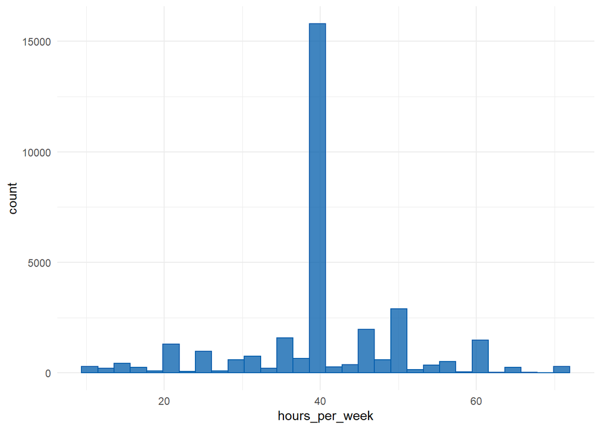

```r
dataFinal %>%
  ggplot(aes(x = hours_per_week)) +
  geom_histogram(alpha = 0.75, show.legend = F,  color = "#005CAB", fill = "#005CAB") +
  theme_minimal()
```

Distribucines similares comparando entre géneros.

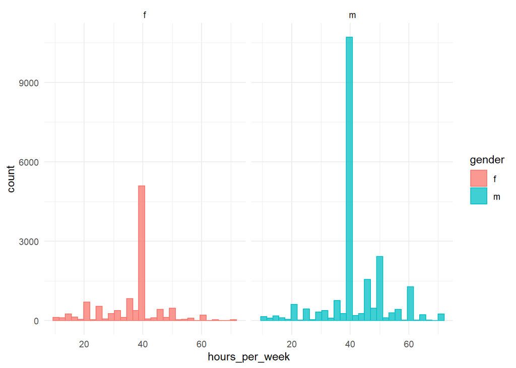

```r
dataFinal %>%
  ggplot(aes(x = hours_per_week, color = gender, fill = gender)) + facet_wrap(~gender) +
  geom_histogram(alpha = 0.75, show.legend = T) +
  theme_minimal()
```

Distribuciones similares comparando la raza.

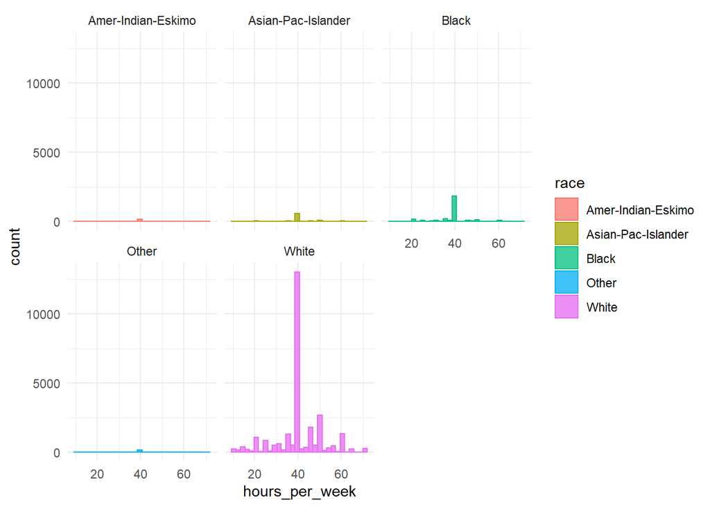

```r
dataFinal %>%
  ggplot(aes(x = hours_per_week, color = race, fill = race)) + facet_wrap(~race) +
  geom_histogram(alpha = 0.75, show.legend = T) +
  theme_minimal()
```

Distribuciones similares en relación al estatus marital.

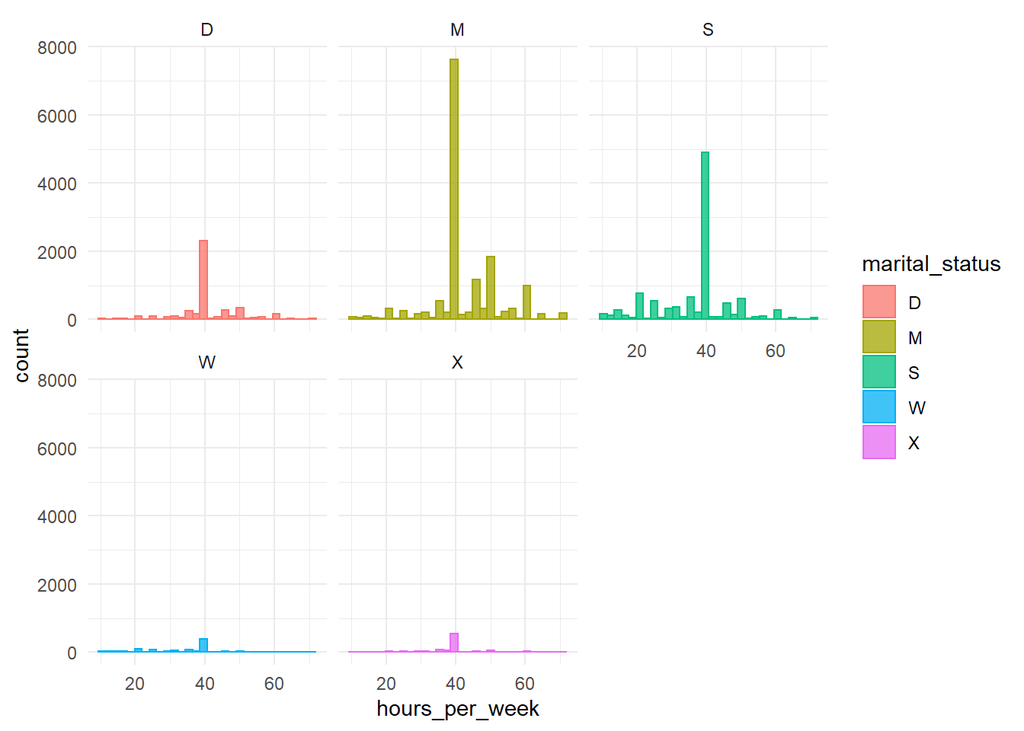

```r
dataFinal %>%
  ggplot(aes(x = hours_per_week, color = marital_status, fill = marital_status)) + facet_wrap(~marital_status) +
  geom_histogram(alpha = 0.75, show.legend = T) +
  theme_minimal()
```

### income

```r
summary(dataFinal$income)
```

```
##    Min. 1st Qu.  Median    Mean 3rd Qu.    Max.
##   26.04   43.22   49.71   48.76   54.32   68.37
```

```r
medidasTendenciaCentral = c(round(mean(dataFinal$income),2),
                            round(media.recortada(dataFinal$income, perc = 0.05),2),
                            round(media.winsor(dataFinal$income, perc = 0.05),2),
                            round(median(dataFinal$income),2))

etiquetasTendenciaCentral = c("Promedio", "Promedio Recortado", "Promedio Winsor","Mediana")
```

```r
tibble(etiquetasTendenciaCentral, medidasTendenciaCentral)
```

```
## # A tibble: 4 x 2
##   etiquetasTendenciaCentral medidasTendenciaCentral
##   <chr>                                       <dbl>
## 1 Promedio                                     48.8
## 2 Promedio Recortado                           48.9
## 3 Promedio Winsor                              48.8
## 4 Mediana                                      49.7
```

La media de la variable se encuentra entre 48.67 y 48.83 en cada 95 de 100 muestras que se analicen.

```r
t.test(x=dataFinal$income, conf.level=0.95)$conf.int
```

```
## [1] 48.67898 48.83304
## attr(,"conf.level")
## [1] 0.95
```

La medida de dispersión robusta es ligeramente menor a la desviación tipica.

```r
medidasDisper <- c(round(sd(dataFinal$income),2),
                   round(winsor.sd(dataFinal$income, trim = 0.05),2)
                   )

etiquetasDisper <- c("Desviación Estándar", "Desviación Winsor")

tibble(etiquetasDisper, medidasDisper)
```

```
## # A tibble: 2 x 2
##   etiquetasDisper     medidasDisper
##   <chr>                       <dbl>
## 1 Desviación Estándar          7.09
## 2 Desviación Winsor            6.72
```

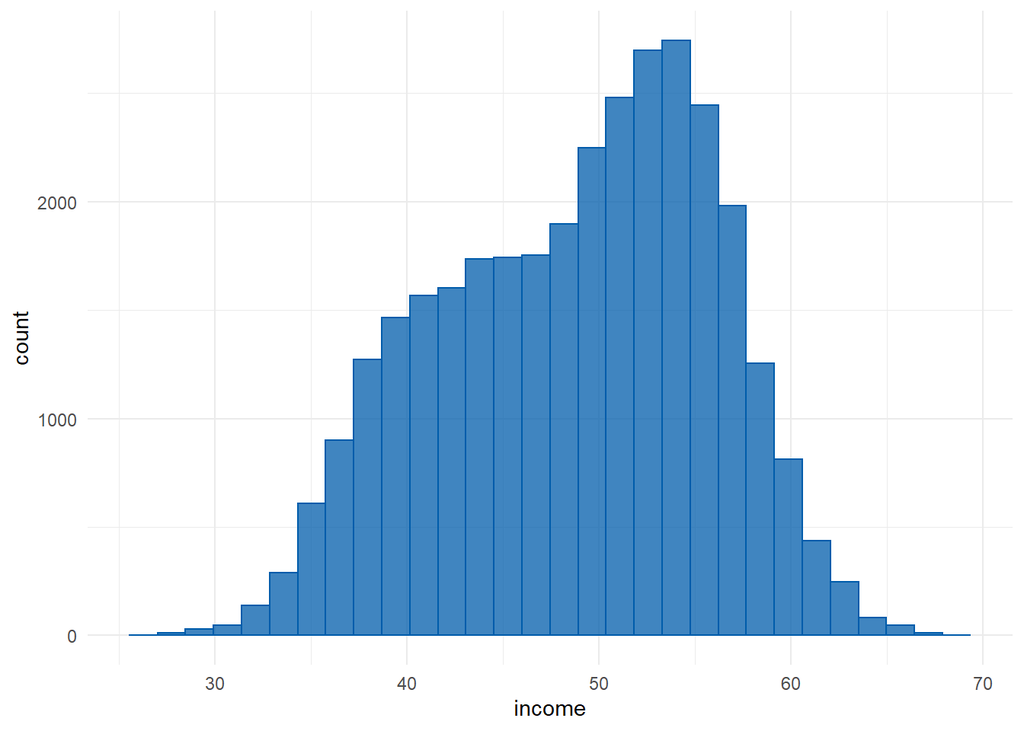

```r
dataFinal %>%
  ggplot(aes(x = income)) +
  geom_histogram(alpha = 0.75, show.legend = F,  color = "#005CAB", fill = "#005CAB") +
  theme_minimal()
```

La distribución de income de los hombres se encuentra más sesgada a la derecha que la distribución de los ingresos de las mujeres.

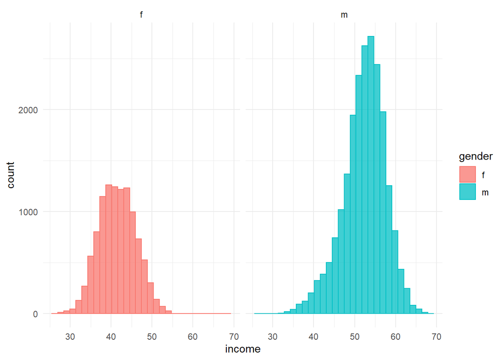

```r
dataFinal %>%
  ggplot(aes(x = income, color = gender, fill = gender)) + facet_wrap(~gender) +
  geom_histogram(alpha = 0.75, show.legend = T) +
  theme_minimal()
```

La distribución de las personas de raza blanca se encuentra ligeramente más sesgada a la derecha.

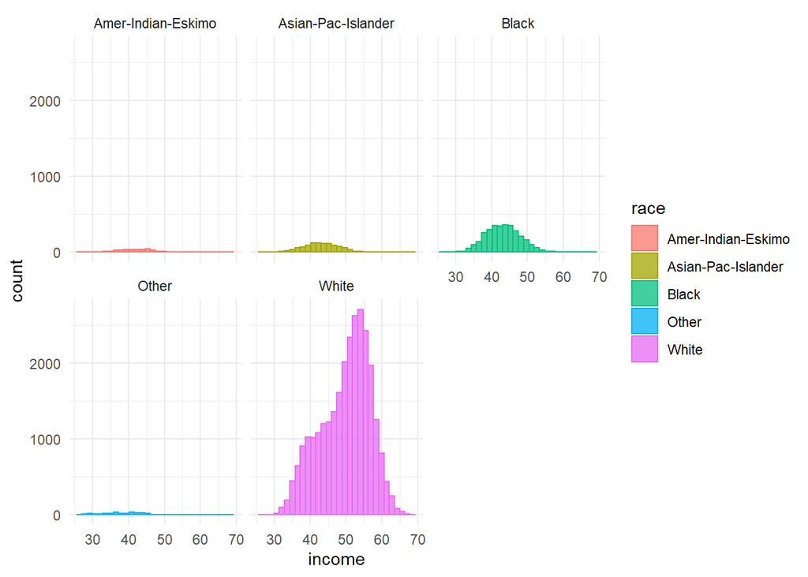

```r
dataFinal %>%
  ggplot(aes(x = income, color = race, fill = race)) + facet_wrap(~race) +
  geom_histogram(alpha = 0.75, show.legend = T) +
  theme_minimal()
```

Las personas casadas tienen una distribución de ingresos un poco más sesgada a la derecha.

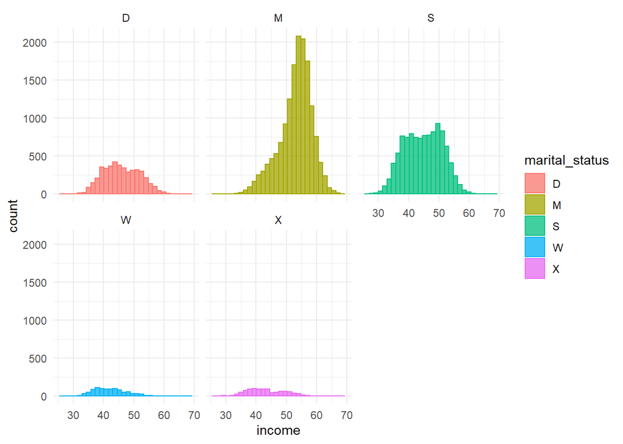

```r
dataFinal %>%
  ggplot(aes(x = income, color = marital_status, fill = marital_status)) + facet_wrap(~marital_status) +
  geom_histogram(alpha = 0.75, show.legend = T) +
  theme_minimal()
```

### Asociación entre variables cuantitativas

Tenemos una correlación moderada baja de 0.33 entre los ingresos y las horas trabajadas a la semana.

```r
matriz_corr <- dataFinal %>%
  select(age, income, education_num, hours_per_week) %>%
  cor(method = "pearson") %>%
  round(2)

matriz_corr
```

```
##                 age income education_num hours_per_week
## age            1.00   0.23          0.10           0.10
## income         0.23   1.00          0.20           0.33
## education_num  0.10   0.20          1.00           0.19
## hours_per_week 0.10   0.33          0.19           1.00
```

# 9.Archivo final

Dejamos las variables tipo bool derivadas del KNN para poder comprobar las imputaciones.

```r
write.csv(dataFinal, "CensusIncome_clean.csv")
```

# Referencias

- E. Vegas Lozano. Preprocesamiento de los datos. UOC